# Análisis Integrado de la Industria de Ensamble y Pintura de Chasis Automotriz Global y de la República Argentina

Vulnerabilidades en la cadena de suministros, dinámicas geopolíticas y transición hacia procesos más limpios en la manufactura automotriz argentina.

María Guadalupe Aguirre Simionato (Instituto de Ingeniería Industrial / Universidad Nacional de Cuyo)https://ingenieria.uncuyo.edu.ar/ , Ignacio Molina Baños (Instituto de Ingeniería Industrial / Universidad Nacional de Cuyo)https://ingenieria.uncuyo.edu.ar/ , Santiago Perez Vicchi (Instituto de Ingeniería Industrial / Universidad Nacional de Cuyo)https://ingenieria.uncuyo.edu.ar/ , Luciano Sfragara (Instituto de Ingeniería Industrial / Universidad Nacional de Cuyo)https://ingenieria.uncuyo.edu.ar/ , Julián Zoia (Instituto de Ingeniería Industrial / Universidad Nacional de Cuyo)https://ingenieria.uncuyo.edu.ar/ , Joaquín Bordón (Instituto de Ingeniería Industrial / Universidad Nacional de Cuyo)https://ingenieria.uncuyo.edu.ar/  
2026-06-05

**Palabras clave:** industria automotriz argentina, ensamblaje de chasis, pintura automotriz, cadena de suministros, riesgo geopolítico, manufactura esbelta.

## 1. Introducción

La industria automotriz argentina constituye uno de los complejos manufactureros de mayor relevancia estructural para la economía nacional, representando aproximadamente el 4,2% del producto industrial bruto y empleando de forma directa e indirecta a más de 130.000 trabajadores (Cámara de la Industria Automotriz Argentina (CIAA), 2024). La fabricación de chasis —componente estructural primario del vehículo— y su posterior proceso de pintura representan, en conjunto, entre el 35% y el 42% del costo total de manufactura de un vehículo ligero o utilitario, constituyéndose en los eslabones de mayor sensibilidad ante variaciones de precios de insumos y perturbaciones logísticas (Groover, 2016).

El ciclo 2024/2025 se ha caracterizado por la confluencia de múltiples shocks externos de naturaleza geopolítica, financiera y tecnológica que han ejercido presión simultánea sobre distintos nodos de la cadena de valor automotriz: el conflicto armado en Ucrania restringió el suministro de acero plano de alta resistencia (AHSS); la reactivación de aranceles seccionales estadounidenses (Sección 232 y Sección 301) reconfiguró los flujos de exportación de partes estampadas; las tensiones en el Estrecho de Ormuz encarecieron los solventes petroquímicos empleados en las líneas de pintura; y la persistente escasez de semiconductores continuó generando inventarios de vehículos con ensamble incompleto en los denominados *parking lots* (Ivanov & Dolgui, 2020; Sodhi et al., 2012).

Frente a este escenario, el presente estudio se propone: (i) caracterizar cuantitativamente la estructura productiva del sector de ensamblaje y pintura de chasis en Argentina; (ii) identificar y cuantificar el impacto de las principales perturbaciones externas sobre los costos unitarios de producción; (iii) diagnosticar los cuellos de botella operativos mediante el análisis de tiempos de ciclo y tasas de defectología por estación; y (iv) evaluar las estrategias de mitigación disponibles en el corto y mediano plazo.

## 2. Marco Teórico

### 2.1 Gestión del Riesgo en Cadenas de Suministro Automotrices

La literatura especializada en gestión de cadenas de suministro ha enfatizado la necesidad de incorporar dimensiones de resiliencia y viabilidad ante disrupciones de naturaleza sistémica (Kleindorfer & Saad, 2005; Mentzer et al., 2001). Ivanov & Dolgui (2020) proponen el concepto de *viabilidad* de redes de suministro interconectadas como extensión de la resiliencia clásica, incorporando la capacidad de supervivencia ante perturbaciones de largo plazo. En el sector automotriz, esta viabilidad se ve condicionada por la elevada especificidad de los activos productivos, los largos tiempos de desarrollo de proveedores alternativos y la rigidez de los estándares técnicos de calidad de componentes (Womack et al., 2007).

## 3. Dimensión Global: Contexto de Mercado y Perturbaciones Geopolíticas

### 3.1 Balances del Mercado Automotriz Mundial (2024/2025)

La producción global de vehículos motorizados alcanzó 92,5 millones de unidades en el período 2024/2025, con China consolidando su posición dominante mediante una cuota del 33% del total manufacturado, seguida por la Unión Europea (19%), Estados Unidos (13%), Japón (10%) e India (6%) (Organisation Internationale des Constructeurs d’Automobiles (OICA), 2024). El mercado de acero estructural destinado a la fabricación de chasis exhibió una presión alcista sostenida del 6,8–7,4% interanual, impulsada por la demanda de vehículos eléctricos y los recortes de producción en acerías europeas (Ternium Argentina S.A., 2024).

### 3.2 Perturbaciones Geopolíticas y Comerciales

La Tabla 1 sintetiza las principales perturbaciones identificadas, el insumo o eslabón afectado, el impacto cuantificado sobre la industria argentina y las estrategias de mitigación disponibles.

Table 1: Table 2: Tabla 1. Perturbaciones geopolíticas y su impacto en la industria de ensamblaje y pintura de chasis argentina (2024/2025). Fuente: elaboración propia.

| Perturbación | Insumo / eslabón afectado | Impacto cuantificado | Estrategia de mitigación |
| --- | --- | --- | --- |
| Guerra Ucrania | Acero AHSS / bobinas laminadas | +22,3% costo acero estructural | Diversificación: CSN/Usiminas (Brasil) |
| Aranceles Secc. 232/301 (EE.UU.) | Partes estampadas exportadas | −14,6% vol. exportado EE.UU. | Redirección hacia mercados Mercosur Sur |
| Conflicto Estrecho de Ormuz | Solventes / energía industrial | +17,8% costo solventes petroquímicos | Transición a pintura base agua |
| Escasez de semiconductores | Módulos ECU / ABS / ESP | +34,2% ciclo WIP; 847 u/mes en espera | Contratos largo plazo con NXP/STMicro |
| Volatilidad zinc LME | Galvanizado de largueros | +19,6% precio spot zinc LME | Cobertura financiera zinc (LME forward) |
| Sequía Canal de Panamá | Componentes electrónicos Asia-Pacífico | +22 días demora promedio entrega | Inventario estratégico 45 días |

La Figura 1 cuantifica el incremento de costos unitarios de producción atribuible a cada perturbación, desagregando el componente directo del indirecto.

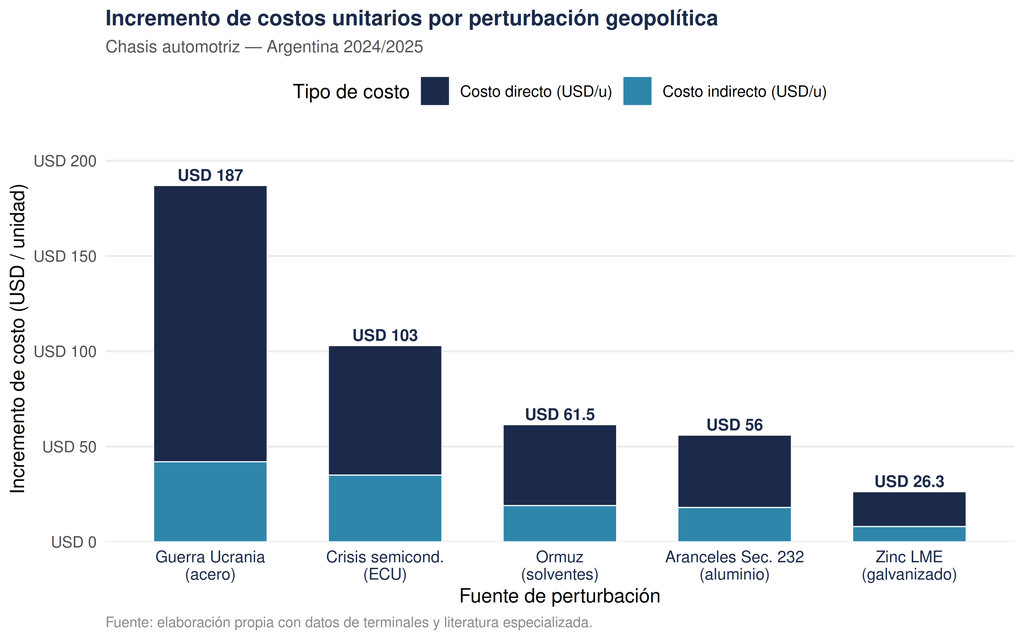

Figure 1: Figura 1. Incremento de costos unitarios por perturbación geopolítica en la industria de ensamblaje de chasis argentina (2024/2025). Fuente: elaboración propia.

## 4. Dimensión Local: Estructura Productiva Argentina

### 4.1 Distribución por Terminal

El sector automotriz argentino cuenta con 11 terminales activas, concentradas principalmente en las provincias de Buenos Aires (48%), Córdoba (35%) y Santa Fe (12%) (Asociación de Fábricas de Automotores (ADEFA), 2024). La Figura 2 presenta la distribución de la producción total de 508.800 unidades del ciclo 2024 por terminal.

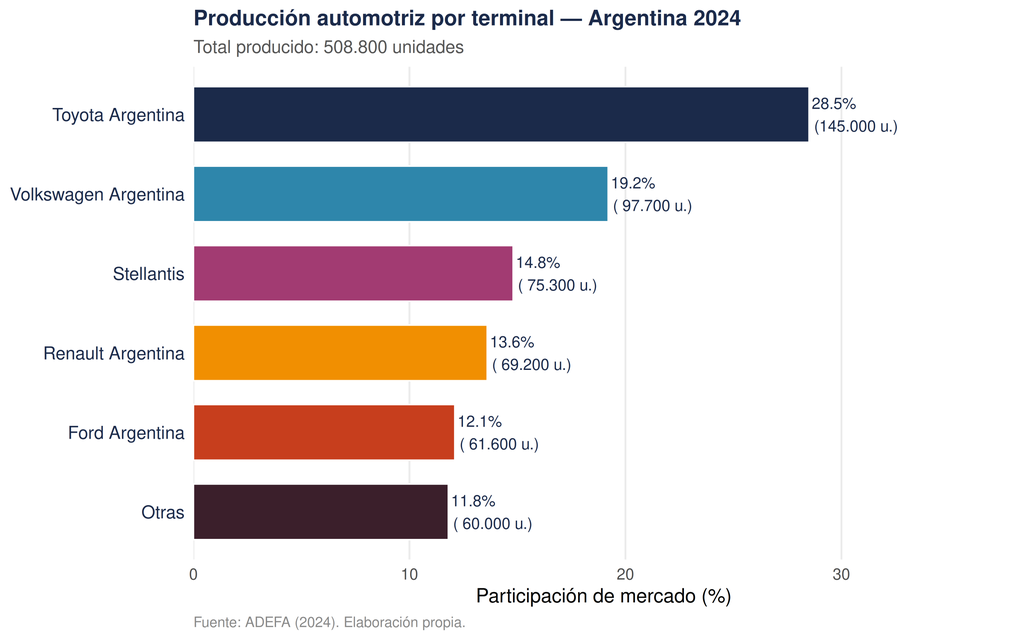

Figure 2: Figura 2. Distribución de la producción automotriz argentina por terminal (2024). Fuente: ADEFA (2024). Elaboración propia.

### 4.2 Evolución de Exportaciones (2019–2024)

El volumen exportado en 2024 alcanzó 308.600 unidades con ingresos FOB de 2.870 millones de USD, representando un crecimiento interanual del 11,4% respecto al ciclo precedente (Asociación de Fábricas de Automotores (ADEFA), 2024; Cámara de la Industria Automotriz Argentina (CIAA), 2024). La Figura 3 ilustra la trayectoria exportadora en el período 2019–2024, evidenciando el impacto de la pandemia COVID-19 en 2020 y la recuperación gradual posterior.

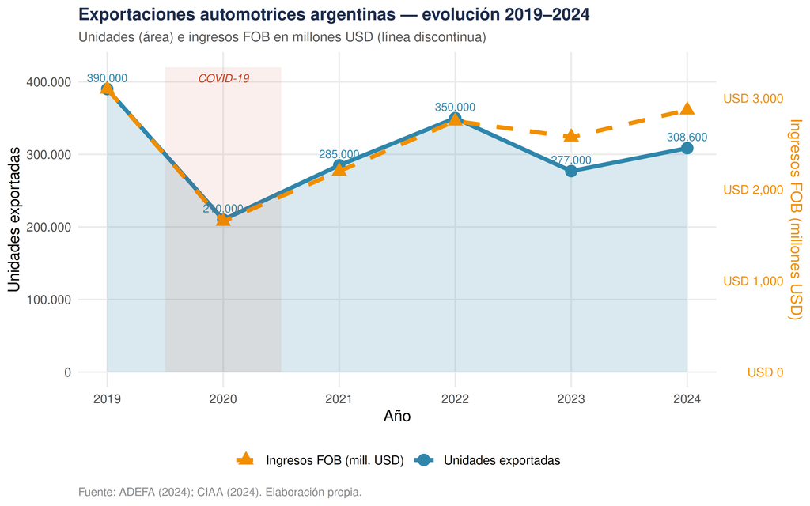

Figure 3: Figura 3. Evolución de las exportaciones automotrices argentinas 2019–2024. Fuente: ADEFA (2024) y CIAA (2024). Elaboración propia.

## 5. Análisis de la Línea de Ensamblaje de Chasis

### 5.1 Diagnóstico por Estación: Tiempos de Ciclo y Defectología

La línea de ensamblaje de chasis comprende siete estaciones secuenciales, cuya cadencia determina la capacidad productiva global del sistema (Shingo, 1989). La Figura 4 superpone los tiempos de ciclo (barras) con la tasa de defectos por millón de partes —DPPM— (línea) para cada estación, identificando visualmente el cuello de botella del sistema.

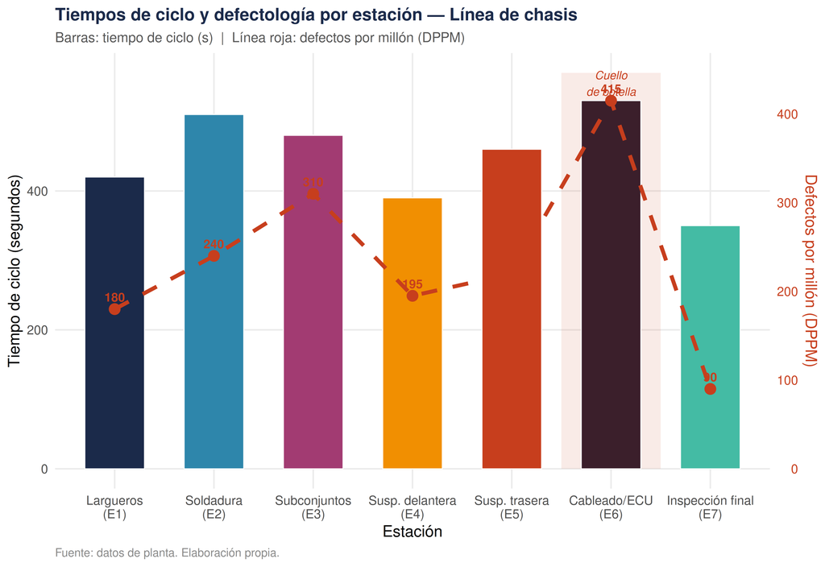

Figure 4: Figura 4. Tiempos de ciclo y tasa de defectos (DPPM) por estación de ensamblaje de chasis. La región sombreada señala el cuello de botella en la Estación 6. Fuente: elaboración propia con datos de planta (2024).

La Estación 6 —integración de cableado y ECU de chasis— presenta el mayor tiempo de ciclo (530 segundos) y la tasa de defectología más elevada (415 DPPM), configurándola como el cuello de botella determinante de la cadencia productiva global. Esta situación es directamente atribuible a la escasez de semiconductores de nodo 28–40 nm que afecta la disponibilidad de módulos ECU, ABS y ESP, generando un incremento del 34,2% en el ciclo de trabajo en proceso (WIP) con un promedio de 847 unidades en estado de ensamble incompleto por período mensual (Sánchez & Ferreyra, 2023).

## 6. Análisis del Proceso de Pintura de Chasis

### 6.1 Indicadores Operativos por Etapa

Table 3: Table 4: Tabla 2. Indicadores operativos de la línea de pintura automotriz (2024). Fuente: datos de planta. Elaboración propia.

Etapa

Temp. (°C)

T. ciclo (min)

Consumo insumo

Rechazo (%)

1. Fosfatado y pretratamiento

52

45

180 L agua/u

1.2

2. Electroforesis catódica (e-coat)

175

30

12,4 kWh/u

0.8

3. Sellado PVC y masillas

140

55

3,2 kg PVC/u

1.5

4. Pintura base (base coat)

85

48

2,8 L pintura/u

2.1

5. Barniz de acabado (clear coat)

140

42

1,9 L barniz/u

1.8

Nota:

Valores de rechazo en rojo indican etapas con tasa superior al umbral crítico del 1,5%.

La Figura 5 presenta de forma comparada los tiempos de ciclo y las tasas de rechazo por etapa mediante un gráfico de *lollipop* facetado.

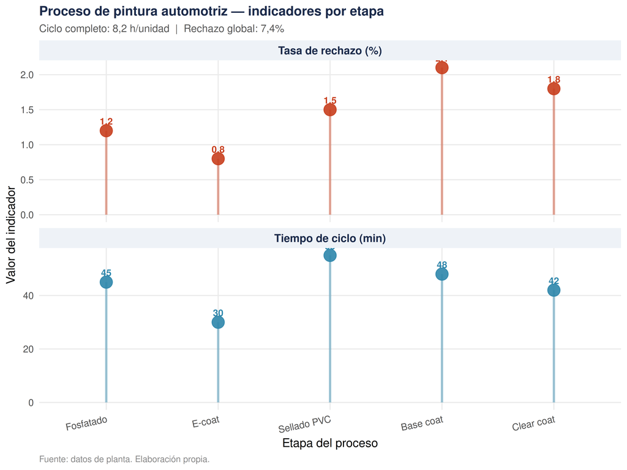

Figure 5: Figura 5. Tiempos de ciclo y tasas de rechazo por etapa del proceso de pintura automotriz. Fuente: elaboración propia con datos de planta (2024).

La etapa de *base coat* registra la mayor tasa de rechazo (2,1%), atribuible a la sensibilidad del proceso a variaciones en la viscosidad de las pinturas solventes ante fluctuaciones de temperatura ambiente en las plantas del NOA durante el período estival. La transición hacia formulaciones base agua proyectada para el año 2026 —con una adopción estimada del 55% de la capacidad instalada— reduciría esta tasa en aproximadamente 0,6 puntos porcentuales, además de cumplir con el mandato de reducción del 35% en emisiones de COV (Chen et al., 2022).

## 7. Vulnerabilidades y Estrategias de Mitigación

### 7.1 Concentración del Suministro de Acero

El 68,4% del acero estructural utilizado en la fabricación de chasis es provisto por Ternium Argentina (ex-Siderar), configurando la vulnerabilidad de proveedor único de mayor criticidad en la cadena de valor local (Ternium Argentina S.A., 2024). La estrategia de diversificación hacia acero importado de origen brasileño —principalmente de Companhia Siderúrgica Nacional (CSN) y Usiminas— implica asumir un sobrecosto logístico estimado en 85 USD/tonelada, compensado parcialmente por la reducción del riesgo de interrupción productiva.

### 7.2 Transición Energética en Procesos de Pintura

La volatilidad de los precios de la energía derivada del conflicto de Ormuz actúa paradójicamente como catalizador de la transición hacia pinturas base agua en las terminales de Zárate (Toyota) y Córdoba (Renault). El ahorro estimado de 28,4 USD/unidad, sumado a la reducción en costos de cumplimiento normativo ambiental, genera un período de retorno de la inversión de conversión de cabinas estimado en 3,8 años (Toyota Motor Argentina S.A., 2023).

### 7.3 Índice OEE y Brecha de Clase Mundial

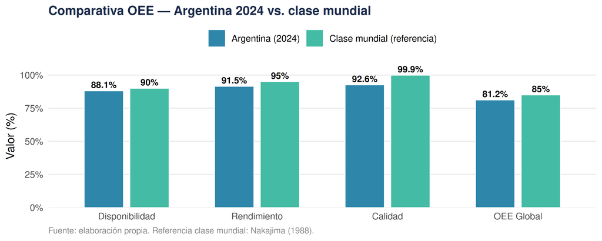

Figure 6: Figura 6. Comparativa OEE: industria automotriz argentina vs. estándar de clase mundial. Fuente: elaboración propia.

## **Referencias**

Asociación de Fábricas de Automotores (ADEFA). (2024). Anuario estadístico de la industria automotriz argentina 2024. *Boletín Estadístico ADEFA*, *41*, 1–128. https://www.adefa.org.ar/estadisticas

Cámara de la Industria Automotriz Argentina (CIAA). (2024). Panorama del sector automotriz argentino: Producción, exportaciones y perspectivas 2024. *Boletín CIAA*. https://www.ciaa.com.ar

Chen, L., Zhao, X., Tang, O., Price, L., Zhang, S., & Zhu, W. (2022). Supply chain collaboration for sustainability: A literature review and future research agenda. *International Journal of Production Economics*, *247*, 108704. https://doi.org/10.1016/j.ijpe.2022.108704

Groover, M. P. (2016). *Fundamentals of modern manufacturing: Materials, processes, and systems* (5th ed.). Wiley.

Ivanov, D., & Dolgui, A. (2020). Viability of intertwined supply networks: Extending the supply chain resilience angles towards survivability. *International Journal of Production Research*, *58*(10), 2904–2915. https://doi.org/10.1080/00207543.2020.1750727

Kleindorfer, P. R., & Saad, G. H. (2005). Managing disruption risks in supply chains. *Production and Operations Management*, *14*(1), 53–68. https://doi.org/10.1111/j.1937-5956.2005.tb00009.x

Mentzer, J. T., DeWitt, W., Keebler, J. S., Min, S., Nix, N. W., Smith, C. D., & Zacharia, Z. G. (2001). Defining supply chain management. *Journal of Business Logistics*, *22*(2), 1–25. https://doi.org/10.1002/j.2158-1592.2001.tb00001.x

Nakajima, S. (1988). *Introduction to TPM: Total productive maintenance*. Productivity Press.

Organisation Internationale des Constructeurs d’Automobiles (OICA). (2024). *World motor vehicle production statistics 2024* [Technical Report]. OICA. https://www.oica.net/production-statistics/

Sánchez, R. A., & Ferreyra, L. M. (2023). Análisis de la vulnerabilidad de la cadena de suministro automotriz argentina ante disrupciones globales. *Revista de Ingeniería Industrial*, *18*(2), 45–68. https://doi.org/10.29191/riia.v18i2.1047

Shingo, S. (1989). *A study of the Toyota production system from an industrial engineering viewpoint*. Productivity Press.

Sodhi, M. S., Son, B.-G., & Tang, C. S. (2012). Researchers’ perspectives on supply chain risk management. *Production and Operations Management*, *21*(1), 1–13. https://doi.org/10.1111/j.1937-5956.2011.01251.x

Ternium Argentina S.A. (2024). *Informe de producción y ventas: Acero plano para autopartes, primer semestre 2024*. https://www.ternium.com/ar/productos-y-servicios/

Toyota Motor Argentina S.A. (2023). *Reporte de sustentabilidad 2023: Planta zárate*. https://www.toyota.com.ar/sustentabilidad

Womack, J. P., Jones, D. T., & Roos, D. (2007). *The machine that changed the world: The story of lean production* (Revised). Free Press.